# Missing Data Analysis

Jemma Nelson, for BH Analytics, LLC

# Objectives

- Understand types of missing data
- Visualize missing data
- Detect and quantify missingness
- Detect and visualize correlated missingness
- Drop missing values
- Recode missing values
- Recode sentinel values into missingness
- Impute missing values

# Missing Data Frameworks

The topic of missing data is an important one. Our natural tendencies are to dismiss missing data and focus on the data points that we have, in order to focus on models, predictions, hypotheses testing and classification. But analysis of missing data can alert us to fundamental issues in our data collection, reporting, or input that can affect the quality of our analyses and predictions.

Missing data falls into 3 categories:

- MCAR - Missing Completely At Random
- MAR - Missing At Random
- MNAR - Missing Not At Random

We’ll discuss these scenarios along with methods to evaluate and impute missing data.

# MCAR - Missing Completely at Random

MCAR data happens when the events that cause missing data are completely independent of the observed data and the unobserved variables, and happens entirely by chance. MCAR is the ‘easiest’ case to deal with, because we can assume that the *missingness* has no bias on estimates and no impact on an analysis. Unfortunately, this type of *missingness* is rarely the case.

- independent of observed
- no impact on estimates or analysis
- rare

# MAR - Missing At Random

MAR data distinguishes itself from MCAR data when there *is* a mechanism that accounts for the missingness. In particular, “there might be systematic differences between the missing and observed values, but these can be entirely explained by other observed variables.” (https://www.ncbi.nlm.nih.gov/pmc/articles/PMC4121561/) In other words, the missingness isn’t related to its own value but is related to the values of other variable in the dataset.

An example of MAR is failure to report income level based on gender. One gender (a variable included in the dataset) might not fill out income level more than another gender.

- systematic difference between missing and observed
- is related to values of other variables
- impacts estimates and analysis
- more common

# MNAR - Missing Not At Random

Lastly, we have the scenario where the data are not missing at random, but the missingness is related to the variable itself. This type of missingness is considered *‘non-ignorable’* and may suggest systematic failures in data collection or recording methods.

Example of MNAR could be that non-compliant diabetic subjects fail to report blood sugar levels more than pre-diabetics, or obese subjects fail to report weight more than other subjects.

- related to the variable itself
- suggests data collection or recording issues
- impacts estimates and analysis
- more common

# Missing value strategies

Missing value strategies based on non-ignorable or problematic missing values could include:

- Reviewing data collection methods
- Reconsidering study design
- Reviewing data coding or input methods
- Dropping cases with missing values
- Imputing missing values

# Missing data in R

Recall that missing data in R is represented by `NA`. A blank is not the same thing as missing!

R also has support for `nan` (not a number), and `inf` (infinity). These are not all equal!

```r
# Sample missing data
x1 <-
  c(1,2,NA,NaN,Inf,3,999)

# this detects only the nan
x1[is.nan(x1)]
```

```
## [1] NaN
```

```r
# this misses infinity, but gets the NA and the NaN
x1[is.na(x1)]
```

```
## [1]  NA NaN
```

```r
# this detect infinity but misses the NA and NaN
x1[is.infinite(x1)]
```

```
## [1] Inf
```

- We should use the `NA` operator for missing data. We can recode the data manually by replacing any odd values as missing:

```r
# recode 99 and 999 to NA
x1[x1 %in% c(999,99)] <- NA
# recode Inf and NaN to NA
x1[is.nan(x1) | is.infinite(x1)] <- NA
x1
```

```
## [1]  1  2 NA NA NA  3 NA
```

- And here are some character examples:

```r
x2 <-
  c('a','b',NA,'',' ')
# catches NA but not the blanks
is.na(x2)
```

```
## [1] FALSE FALSE  TRUE FALSE FALSE
```

```r
x2[is.na(x2)]
```

```
## [1] NA
```

```r
# returns the blank and NA for the NA!
x2 == ''
```

```
## [1] FALSE FALSE    NA  TRUE FALSE
```

```r
x2[x2 == '']
```

```
## [1] NA ""
```

```r
# returns the space and NA for the NA!
x2[x2 == ' ']
```

```
## [1] NA  " "
```

```r
# recode
x2[x2 %in% c('',' ')] <- NA
x2
```

```
## [1] "a" "b" NA  NA  NA
```

# Exercise

- Create a vector with 3 values in it.
- Factor the vector, but only declare 2 of the 3 levels with the `levels=` option.
- What happens? Detect the missing value.

# Answer

```r
ff <- factor(c('red','green','blue'), levels=c('red','green'))
ff
```

```
## [1] red   green <NA>
## Levels: red green
```

```r
is.na(ff)
```

```
## [1] FALSE FALSE  TRUE
```

# Exercise

Try to use `==` to detect the missing value from your vector above. Why does this fail?

# Answer

```r
ff == NA
```

```
## [1] NA NA NA
```

```r
# this fails because we can't say anything about missingness. We can't compare it to anything else.
```

# Recoding Missing Values

We can recode missing values in a variety of ways:

- by combining detection and setting patterns
- by using convenience functions

# Recoding Missing Values in base and `dplyr`

In base R, we can use `ifelse` to recode values in a vector. In dplyr, if we want to recode sentinel values as missing values, we can do so within a `mutate` statement and use `na_if`

```r
library(dplyr)
a <- c(1,2,-999)
ifelse(a==-999,NA,a) # if it matches, replace with NA, otherwise pass the value through
```

```
## [1]  1  2 NA
```

```r
#
df <- tibble::tibble(A=c(1,2,-999),B=c('Unknown','red','blue'))
df
```

```
## # A tibble: 3 x 2
##       A B
##   <dbl> <chr>
## 1     1 Unknown
## 2     2 red
## 3  -999 blue
```

```r
df %>%
  mutate(A = ifelse(A==-999,NA,A)) #as above
```

```
## # A tibble: 3 x 2
##       A B
##   <dbl> <chr>
## 1     1 Unknown
## 2     2 red
## 3    NA blue
```

```r
df %>%
  mutate(A = na_if(A,-999)) # or using the convenience function
```

```
## # A tibble: 3 x 2
##       A B
##   <dbl> <chr>
## 1     1 Unknown
## 2     2 red
## 3    NA blue
```

# Recoding Multiple Columns in `dplyr`

For multiple columns, we need to do a little bit more programming, and use helper verbs. However, `na_if` can only handle one “sentinel” value. If you have to recode multiple values, you need to chain statements together.

```r
df %>%
  mutate_all(~na_if(.x,-999))
```

```
## # A tibble: 3 x 2
##       A B
##   <dbl> <chr>
## 1     1 Unknown
## 2     2 red
## 3    NA blue
```

```r
df %>%
  mutate_all(~na_if(.x,-999)) %>%
  mutate_all(~na_if(.x,"Unknown"))
```

```
## # A tibble: 3 x 2
##       A B
##   <dbl> <chr>
## 1     1 <NA>
## 2     2 red
## 3    NA blue
```

# Recoding In `data.table`

- We can recode in data.table using our assignment operator and a matching condition in I
- We can chain statements together

```r
library(data.table)
dt <- data.table(df)
dt
```

```
##       A       B
## 1:    1 Unknown
## 2:    2     red
## 3: -999    blue
```

```r
dt[A==-999,A:=NA]
#
dt[A==-999,A:=NA][B=="Unknown",B:=NA]
dt
```

```
##     A    B
## 1:  1 <NA>
## 2:  2  red
## 3: NA blue
```

# Exercise

1. Import the data set `pima.csv` into R
2. Set the column names as: `c('npreg','glu','bp','skin','insulin','bmi','ped','age','type')`
3. Examine the data set and data types.
4. Consider the following data dictionary:

`npreg` number of pregnancies.

`glu` plasma glucose concentration in an oral glucose tolerance test.

`bp` diastolic blood pressure (mm Hg).

`skin` triceps skin fold thickness (mm).

`insulin` 2-hr serum insulin (muU/ml).

`bmi` body mass index (weight in kg/(height in m)^2).

`ped` diabetes pedigree function.

`age` age in years.

`type` Yes or No, for diabetic according to WHO criteria.

4. What constitutes a **missing value** in this dataset?

# Answer

```r
pima <- fread("Data/pima.csv",header = F)
pima <- setnames(pima,c('npreg','glu','bp','skin','insulin','bmi','ped','age','type'))
summary(pima) # No missing values?
```

```
##      npreg             glu              bp              skin          insulin           bmi             ped              age             type
##  Min.   : 0.000   Min.   :  0.0   Min.   :  0.00   Min.   : 0.00   Min.   :  0.0   Min.   : 0.00   Min.   :0.0780   Min.   :21.00   Min.   :0.000
##  1st Qu.: 1.000   1st Qu.: 99.0   1st Qu.: 62.00   1st Qu.: 0.00   1st Qu.:  0.0   1st Qu.:27.30   1st Qu.:0.2437   1st Qu.:24.00   1st Qu.:0.000
##  Median : 3.000   Median :117.0   Median : 72.00   Median :23.00   Median : 30.5   Median :32.00   Median :0.3725   Median :29.00   Median :0.000
##  Mean   : 3.845   Mean   :120.9   Mean   : 69.11   Mean   :20.54   Mean   : 79.8   Mean   :31.99   Mean   :0.4719   Mean   :33.24   Mean   :0.349
##  3rd Qu.: 6.000   3rd Qu.:140.2   3rd Qu.: 80.00   3rd Qu.:32.00   3rd Qu.:127.2   3rd Qu.:36.60   3rd Qu.:0.6262   3rd Qu.:41.00   3rd Qu.:1.000
##  Max.   :17.000   Max.   :199.0   Max.   :122.00   Max.   :99.00   Max.   :846.0   Max.   :67.10   Max.   :2.4200   Max.   :81.00   Max.   :1.000
```

```r
# Can blood pressure be 0? Can skin thickness be 0?
# maybe some of the 0's should be missing values...we'll recode them next
```

# Exercise Recoding Values

1. Recode values in the `pima` dataset into missing values. Only do this for the columns where a zero doesn’t make sense.
1. Hint: use a helper verb, like `mutate_at`
2. Save this data set, we’ll explore it more.

# Answer

```r
pima <- pima %>%
  mutate_at(vars(glu,bp,skin,insulin,bmi),~na_if(.x,0))
```

# Loading the data

For the next section chapter, we’ll use the Horse Colic data set from the UCI Machine learning repository (https://archive.ics.uci.edu/ml/datasets/Horse+Colic)

Load the data using data.table or readr or base R!

# Exercise

First, look at the plain text file. How is missing data represented? Try reading in the data using readr or base R with whitespace as a delimiter. What are the resulting datatypes of the columns (if you just use the basic command)?

# Answer

```r
library(readr)
horse_colic <- read_table2("Data/horse-colic.txt")
# the columns come in as character, because of the `?` values
glimpse(horse_colic)
```

```
## Rows: 299
## Columns: 28
## $ `2`       <chr> "1", "2", "1", "2", "2", "1", "1", "2", "2", "1", "2", "1", "2", "1", "1", "1", "2", "1", "2", "1", "2", "1", "1", "1", "2", "1",...
## $ `1`       <dbl> 1, 1, 9, 1, 1, 1, 1, 1, 9, 1, 1, 1, 9, 1, 1, 9, 1, 1, 1, 1, 1, 1, 9, 1, 1, 1, 1, 1, 1, 1, 1, 1, 1, 1, 1, 1, 1, 1, 9, 1, 9, 1, 1, ...
## $ `530101`  <dbl> 534817, 530334, 5290409, 530255, 528355, 526802, 529607, 530051, 5299629, 528548, 527927, 528031, 5291329, 534917, 530233, 530121...
## $ `38.50`   <chr> "39.2", "38.30", "39.10", "37.30", "?", "37.90", "?", "?", "38.30", "38.10", "39.10", "37.20", "38.00", "38.2", "37.60", "?", "37...
## $ `66`      <chr> "88", "40", "164", "104", "?", "48", "60", "80", "90", "66", "72", "42", "92", "76", "96", "128", "48", "64", "110", "72", "48", ...
## $ `28`      <chr> "20", "24", "84", "35", "?", "16", "?", "36", "?", "12", "52", "12", "28", "28", "48", "36", "24", "21", "35", "60", "16", "34", ...
## $ `3`       <chr> "?", "1", "4", "?", "2", "1", "3", "3", "1", "3", "2", "2", "1", "3", "3", "3", "?", "1", "4", "1", "1", "2", "?", "3", "?", "4",...
## $ `3_1`     <chr> "?", "1", "1", "?", "1", "1", "?", "4", "?", "3", "?", "1", "1", "1", "1", "3", "?", "1", "3", "1", "?", "1", "3", "3", "?", "3",...
## $ `?`       <chr> "4", "3", "6", "6", "3", "1", "?", "3", "1", "5", "2", "1", "2", "1", "4", "4", "?", "2", "6", "5", "1", "4", "?", "3", "?", "3",...
## $ `2_1`     <chr> "1", "1", "2", "2", "1", "1", "1", "1", "1", "1", "1", "1", "1", "1", "1", "2", "?", "1", "?", "2", "1", "?", "1", "1", "1", "2",...
## $ `5`       <chr> "3", "3", "2", "?", "2", "3", "?", "4", "5", "3", "2", "3", "1", "3", "5", "4", "?", "2", "?", "5", "1", "2", "2", "?", "?", "3",...
## $ `4`       <chr> "4", "3", "4", "?", "3", "3", "4", "4", "3", "3", "1", "3", "3", "4", "3", "4", "?", "3", "3", "4", "3", "3", "4", "4", "?", "3",...
## $ `4_1`     <chr> "2", "1", "4", "?", "2", "3", "2", "4", "1", "1", "2", "3", "2", "1", "3", "3", "?", "1", "3", "4", "1", "1", "?", "3", "?", "3",...
## $ `?_1`     <chr> "?", "?", "1", "?", "2", "1", "2", "2", "2", "2", "1", "3", "3", "2", "2", "3", "?", "1", "?", "3", "2", "?", "?", "3", "?", "2",...
## $ `?_2`     <chr> "?", "?", "2", "?", "1", "1", "1", "1", "1", "1", "1", "1", "?", "2", "3", "?", "?", "1", "?", "1", "3", "?", "?", "2", "?", "1",...
## $ `?_3`     <chr> "?", "?", "5.00", "?", "?", "?", "?", "?", "?", "3.00", "?", "?", "7.20", "?", "4.50", "?", "?", "?", "?", "?", "5.50", "?", "?",...
## $ `3_2`     <chr> "4", "1", "3", "?", "3", "3", "3", "3", "3", "2", "4", "4", "1", "4", "4", "4", "?", "2", "?", "4", "4", "1", "?", "?", "?", "3",...
## $ `5_1`     <chr> "2", "1", "?", "?", "3", "5", "4", "5", "?", "5", "4", "5", "1", "4", "?", "5", "?", "5", "?", "4", "3", "?", "?", "?", "?", "5",...
## $ `45.00`   <chr> "50", "33.00", "48.00", "74.00", "?", "37.00", "44.00", "38.00", "40.00", "44.00", "50.00", "?", "37.00", "46", "45.00", "53.00",...
## $ `8.40`    <chr> "85", "6.70", "7.20", "7.40", "?", "7.00", "8.30", "6.20", "6.20", "6.00", "7.80", "7.00", "6.10", "81", "6.80", "7.80", "?", "7....
## $ `?_4`     <chr> "2", "?", "3", "?", "?", "?", "?", "?", "1", "2", "?", "?", "1", "1", "?", "3", "?", "1", "?", "2", "?", "?", "?", "?", "?", "2",...
## $ `?_5`     <chr> "2", "?", "5.30", "?", "?", "?", "?", "?", "2.20", "3.60", "?", "?", "?", "2", "?", "4.70", "?", "?", "?", "?", "?", "?", "?", "?...
## $ `2_2`     <chr> "3", "1", "2", "2", "1", "1", "2", "3", "1", "1", "1", "1", "2", "1", "2", "2", "1", "1", "1", "1", "1", "1", "1", "1", "1", "1",...
## $ `2_3`     <dbl> 2, 2, 1, 2, 2, 1, 1, 1, 2, 1, 1, 2, 2, 1, 1, 2, 2, 1, 2, 1, 2, 1, 1, 1, 2, 1, 2, 2, 2, 1, 1, 1, 1, 1, 1, 2, 1, 2, 1, 1, 1, 2, 1, ...
## $ `11300`   <chr> "02208", "00000", "02208", "04300", "00000", "03124", "02208", "03205", "00000", "02124", "02111", "04124", "00000", "02112", "03...
## $ `00000`   <chr> "00000", "00000", "00000", "00000", "00000", "00000", "00000", "00000", "00000", "00000", "00000", "00000", "00000", "00000", "00...
## $ `00000_1` <chr> "00000", "00000", "00000", "00000", "00000", "00000", "00000", "00000", "00000", "00000", "00000", "00000", "00000", "00000", "00...
## $ `2_4`     <dbl> 2, 1, 1, 2, 2, 2, 2, 2, 1, 1, 2, 2, 1, 2, 2, 1, 2, 1, 2, 2, 2, 2, 2, 2, 2, 1, 1, 2, 2, 2, 1, 2, 1, 2, 2, 1, 2, 1, 2, 2, 1, 2, 2, ...
```

# Loading the data

```r
library(data.table)
colic <-
  fread('Data/horse-colic.txt',
        header = FALSE,na.strings = '?')
head(colic)
```

```
##    V1 V2      V3   V4  V5 V6 V7 V8 V9 V10 V11 V12 V13 V14 V15 V16 V17 V18 V19  V20 V21 V22 V23 V24   V25 V26 V27 V28
## 1:  2  1  530101 38.5  66 28  3  3 NA   2   5   4   4  NA  NA  NA   3   5  45  8.4  NA  NA   2   2 11300   0   0   2
## 2:  1  1  534817 39.2  88 20 NA NA  4   1   3   4   2  NA  NA  NA   4   2  50 85.0   2 2.0   3   2  2208   0   0   2
## 3:  2  1  530334 38.3  40 24  1  1  3   1   3   3   1  NA  NA  NA   1   1  33  6.7  NA  NA   1   2     0   0   0   1
## 4:  1  9 5290409 39.1 164 84  4  1  6   2   2   4   4   1   2   5   3  NA  48  7.2   3 5.3   2   1  2208   0   0   1
## 5:  2  1  530255 37.3 104 35 NA NA  6   2  NA  NA  NA  NA  NA  NA  NA  NA  74  7.4  NA  NA   2   2  4300   0   0   2
## 6:  2  1  528355   NA  NA NA  2  1  3   1   2   3   2   2   1  NA   3   3  NA   NA  NA  NA   1   2     0   0   0   2
```

Let’s first drop some of the columns that are not of interest to us..and then let’s name the columns according to the data description. https://archive.ics.uci.edu/ml/datasets/Horse+Colic

colic.columns = c(‘surgery’,‘young_age’,‘hospital_ID’,‘rectal_temp’,‘pulse’,‘resp_rate’, ‘extremities_temp’,‘peripheral_pulse’,‘mucous_membranes’, ‘cap_refill_time’,‘pain’,‘peristalsis’,‘abdominal_distension’, ‘nasogastric_tube’,‘nasogastric_reflux’,‘ng_rfx_PH’,‘feces’, ‘abdomen’,‘packed_cell_volume’,‘total_protein’, ‘abdominocentesis_appearance’,‘abcs_tot_protein’,‘outcome’)

```r
colic <-
  colic[,1:23]
colic.columns <-
  c('surgery','young_age','hospital_ID','rectal_temp','pulse','resp_rate',
    'extremities_temp','peripheral_pulse','mucous_membranes','cap_refill_time',
    'pain','peristalsis','abdominal_distension','nasogastric_tube',
    'nasogastric_reflux','ng_rfx_PH','feces','abdomen','packed_cell_volume',
    'total_protein','abdominocentesis_appearance','abcs_tot_protein','outcome')
setnames(colic,colic.columns)
head(colic)
```

```
##    surgery young_age hospital_ID rectal_temp pulse resp_rate extremities_temp peripheral_pulse mucous_membranes cap_refill_time pain peristalsis
## 1:       2         1      530101        38.5    66        28                3                3               NA               2    5           4
## 2:       1         1      534817        39.2    88        20               NA               NA                4               1    3           4
## 3:       2         1      530334        38.3    40        24                1                1                3               1    3           3
## 4:       1         9     5290409        39.1   164        84                4                1                6               2    2           4
## 5:       2         1      530255        37.3   104        35               NA               NA                6               2   NA          NA
## 6:       2         1      528355          NA    NA        NA                2                1                3               1    2           3
##    abdominal_distension nasogastric_tube nasogastric_reflux ng_rfx_PH feces abdomen packed_cell_volume total_protein abdominocentesis_appearance
## 1:                    4               NA                 NA        NA     3       5                 45           8.4                          NA
## 2:                    2               NA                 NA        NA     4       2                 50          85.0                           2
## 3:                    1               NA                 NA        NA     1       1                 33           6.7                          NA
## 4:                    4                1                  2         5     3      NA                 48           7.2                           3
## 5:                   NA               NA                 NA        NA    NA      NA                 74           7.4                          NA
## 6:                    2                2                  1        NA     3       3                 NA            NA                          NA
##    abcs_tot_protein outcome
## 1:               NA       2
## 2:              2.0       3
## 3:               NA       1
## 4:              5.3       2
## 5:               NA       2
## 6:               NA       1
```

# Horse Colic

Horse colic is a common (4-10%) and potentially life-threatening condition for horses. It’s a condition that represents intestinal pain, can onset suddenly, and can require expensive surgery. It is the leading cause of death for domesticated horses. This data represents several veterinary features related to horse colic.

# How much missing?

Let’s analyze how much of this data set is missing. We can think about this two ways - quantifying missingness by row, or quantifying missingness by column.

We will start by column. There are a few ways to do this, but I chose to use the apply function and identify the function should be applied across the columns. The result is the total number of missing per column.

```r
## total missing by column
missing_column <-
  apply(colic,MARGIN = 2,function(x) sum(is.na(x)))
missing_column
```

```
##                     surgery                   young_age                 hospital_ID                 rectal_temp                       pulse
##                           1                           0                           0                          60                          24
##                   resp_rate            extremities_temp            peripheral_pulse            mucous_membranes             cap_refill_time
##                          58                          56                          69                          47                          32
##                        pain                 peristalsis        abdominal_distension            nasogastric_tube          nasogastric_reflux
##                          55                          44                          56                         104                         106
##                   ng_rfx_PH                       feces                     abdomen          packed_cell_volume               total_protein
##                         247                         102                         118                          29                          33
## abdominocentesis_appearance            abcs_tot_protein                     outcome
##                         165                         198                           1
```

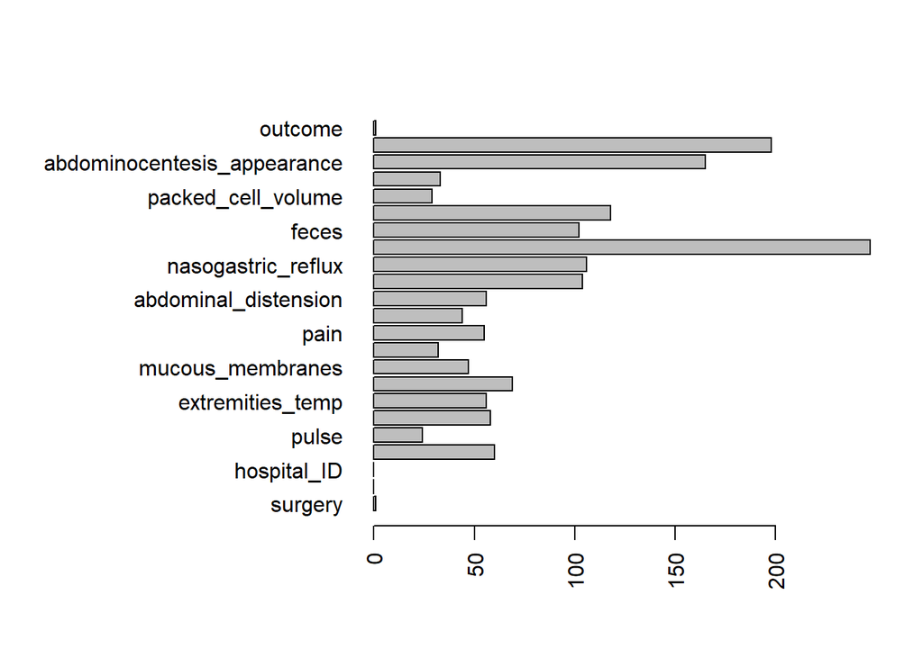

```r
# change the margins
par(mar = c(5,14,4,2))
barplot(missing_column,
        horiz = TRUE,
        las = 2)
```

# Missing by Row

We can also analyze this by row by changing the margin argument. This results in a vector as long as the original number of rows, so I have further summarized it a bit (rather than print hundreds of values!)

```r
## total missing by row
missing_row <-
  apply(colic,MARGIN = 1,function(x) sum(is.na(x)))
head(missing_row)
```

```
## [1]  6  5  5  1 12  8
```

```r
## How many rows are missing 5 or more?
sum(missing_row>5) # 108
```

```
## [1] 108
```

```r
sum(missing_row>5)/length(missing_row) # 36%
```

```
## [1] 0.36
```

# Visualizing the missing Data

There is a handy and simple package called `visdat` that will visualize the missing data for us as well. But this won’t work very well for big datasets.

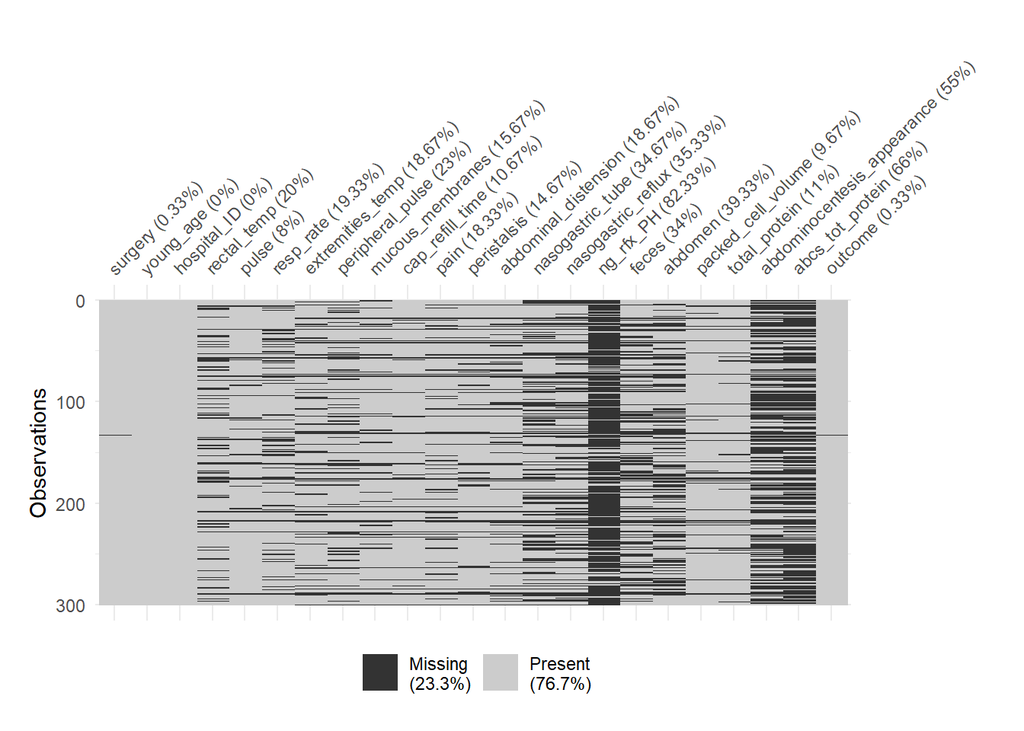

```r
# use the visdat package to visualize the missing
library(visdat)
library(ggplot2)
plt1 <- vis_miss(colic)
# I manually changed the margins here so the text doesn't clip.
# This function returns a ggplot so I must use that too...
plt1 +
  theme(plot.margin = unit(c(0.5,3,0.5,0.5), "cm"))
```

```r
# this would be more challenging to use with a lot of rows though!
```

# Drop rows with missing data

We could drop any row with a missing value. In the horse colic case, where some rows have severely missing data, the data reduction is a little bit drastic, leaving us with only 6 rows!

```r
# drop any rows with missing data, return dataframe
colic_2 <-
  na.omit(colic)
colic_2 # only 6 left!
```

```
##    surgery young_age hospital_ID rectal_temp pulse resp_rate extremities_temp peripheral_pulse mucous_membranes cap_refill_time pain peristalsis
## 1:       1         1      528548        38.1    66        12                3                3                5               1    3           3
## 2:       2         1      529461        40.3   114        36                3                3                1               2    2           3
## 3:       1         1      529667        39.0    64        36                3                1                4               2    3           3
## 4:       2         1      529461        40.3   114        36                3                3                1               2    2           3
## 5:       1         1      527563        37.8    52        24                1                3                3               1    4           4
## 6:       1         1     5299603        38.3    60        16                3                1                1               1    2           1
##    abdominal_distension nasogastric_tube nasogastric_reflux ng_rfx_PH feces abdomen packed_cell_volume total_protein abdominocentesis_appearance
## 1:                    1                2                  1       3.0     2       5                 44           6.0                           2
## 2:                    3                2                  1       7.0     1       5                 57           8.1                           3
## 3:                    2                1                  2       7.0     4       5                 44           7.5                           3
## 4:                    3                2                  1       7.0     1       5                 57           8.1                           3
## 5:                    1                2                  3       5.7     2       5                 48           6.6                           1
## 6:                    1                2                  2       3.0     1       4                 30           6.0                           1
##    abcs_tot_protein outcome
## 1:              3.6       1
## 2:              4.5       3
## 3:              5.0       1
## 4:              4.5       2
## 5:              3.7       2
## 6:              3.0       1
```

# Complete Cases

Instead we could focus on specific columns.

```r
# only drop based on specific columns - young age and pain in this case
colic_3 <-
  colic[complete.cases(colic[,list(young_age,pain)])]
# this leaves 245 rows!
```

# Exercise

1. Quantify the missing data in the `pima` dataset.
1. How much data is missing per variable?
2. If you drop rows with any missing data, how many rows do you have left?

# Answer

```r
summary(pima)
```

```
##      npreg             glu              bp              skin          insulin            bmi             ped              age             type
##  Min.   : 0.000   Min.   : 44.0   Min.   : 24.00   Min.   : 7.00   Min.   : 14.00   Min.   :18.20   Min.   :0.0780   Min.   :21.00   Min.   :0.000
##  1st Qu.: 1.000   1st Qu.: 99.0   1st Qu.: 64.00   1st Qu.:22.00   1st Qu.: 76.25   1st Qu.:27.50   1st Qu.:0.2437   1st Qu.:24.00   1st Qu.:0.000
##  Median : 3.000   Median :117.0   Median : 72.00   Median :29.00   Median :125.00   Median :32.30   Median :0.3725   Median :29.00   Median :0.000
##  Mean   : 3.845   Mean   :121.7   Mean   : 72.41   Mean   :29.15   Mean   :155.55   Mean   :32.46   Mean   :0.4719   Mean   :33.24   Mean   :0.349
##  3rd Qu.: 6.000   3rd Qu.:141.0   3rd Qu.: 80.00   3rd Qu.:36.00   3rd Qu.:190.00   3rd Qu.:36.60   3rd Qu.:0.6262   3rd Qu.:41.00   3rd Qu.:1.000
##  Max.   :17.000   Max.   :199.0   Max.   :122.00   Max.   :99.00   Max.   :846.00   Max.   :67.10   Max.   :2.4200   Max.   :81.00   Max.   :1.000
##                   NA's   :5       NA's   :35       NA's   :227     NA's   :374      NA's   :11
```

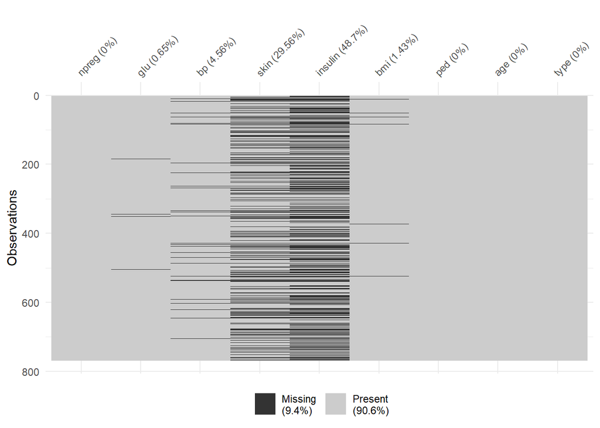

```r
vis_miss(pima)
```

```r
nrow(pima)
```

```
## [1] 768
```

```r
nrow(na.omit(pima)) #almost half missing!
```

```
## [1] 392
```

# Assessing missing at random versus missing completely at random

Recall it is hard (or impossible) to test for missing not at random, since I don’t know what I don’t know.

However, we can try to assess missingness and see if it seems to be related to other variables in the dataset. One way to do that is to use the `naniar` package, which has a nice extra piece added on to ggplot to examine distributions. We will focus on pulse and rectal temp in this dataset for now.

Here is an example of one way to examine the distribution across missing / non-missing status. Notice the regular ggplot call excludes missing values:

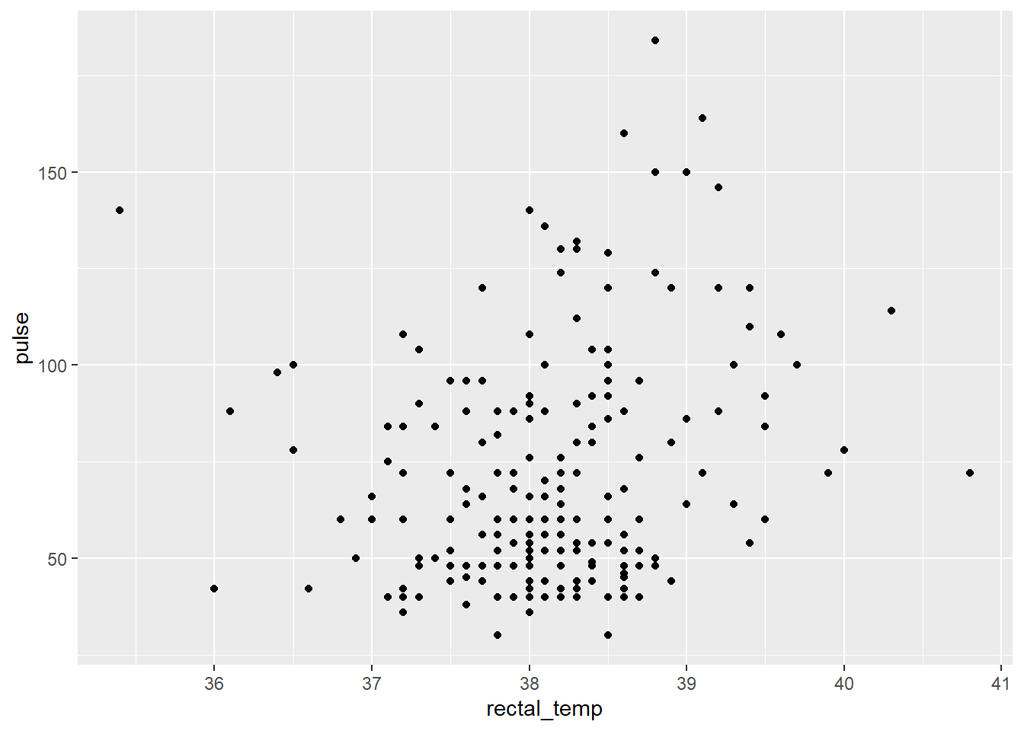

```r
ggplot(colic,
       aes(x = rectal_temp,
           y = pulse)) +
  geom_point()
```

However, if we add `naniar` and the `geom_miss_point()`, we will get a distribution of points along the X and Y axis that allow us to examine the distribution of missing versus non-missing values.

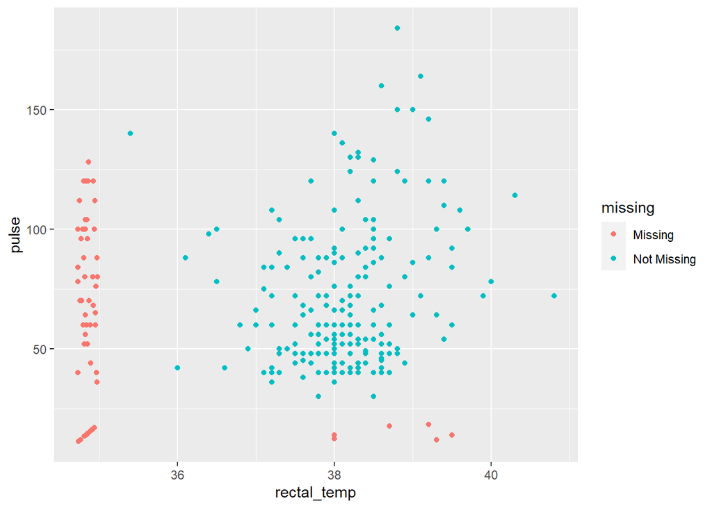

```r
library(naniar)
# Missing values are added along the X and Y axis
ggplot(colic,
       aes(x = rectal_temp,
           y = pulse)) +
  geom_miss_point()
```

The red data points in the lower left corner are where both variables are missing. That is not useful to see here. However, the red points along the bottom of the graph are missing pulse but not missing rectal temperature. The question we ask ourselves then is, ‘Does this distribution look different than the distribution right above it?’

We could try to ask that question more directly by simply calculating some summary statistics across the missing and non missing values as well.

```r
# check average pulse across missing rectal temp
colic[,list(mean_pulse = mean(pulse,na.rm=T)),
      by = list(rt_miss = is.na(rectal_temp))]
```

```
##    rt_miss mean_pulse
## 1:   FALSE   70.23504
## 2:    TRUE   81.26190
```

It looks like the mean pulse of horses missing rectal temp is higher than the mean pulse in those not missing rectal temp. This would support the idea that the missingness in rectal temp is MAR instead of MCAR, since it seems to be related to pulse. That is a bit harder to see in the graph above though. Sometimes it is better to directly code / calculate these things…

# Imputing the mean or median in a dataset

So what to do if we have missing data? We could consider simply imputing one value based on the full distribution of only that value. One method of doing that would be imputing the mean (or the median). In the case of the pulse variable, we would simply write code like the following:

```r
# copy dataset first
colic_new <-
  copy(colic)
# convert int to numeric
colic_new[,pulse := as.numeric(pulse)]
# impute mean by column
colic_new[,
          pulse_mean_impute:=pulse]
colic_new[is.na(pulse),
          pulse_mean_impute:=colic_new[,mean(pulse,na.rm=TRUE)]]
# what happened?
hist(colic_new$pulse,15)
```

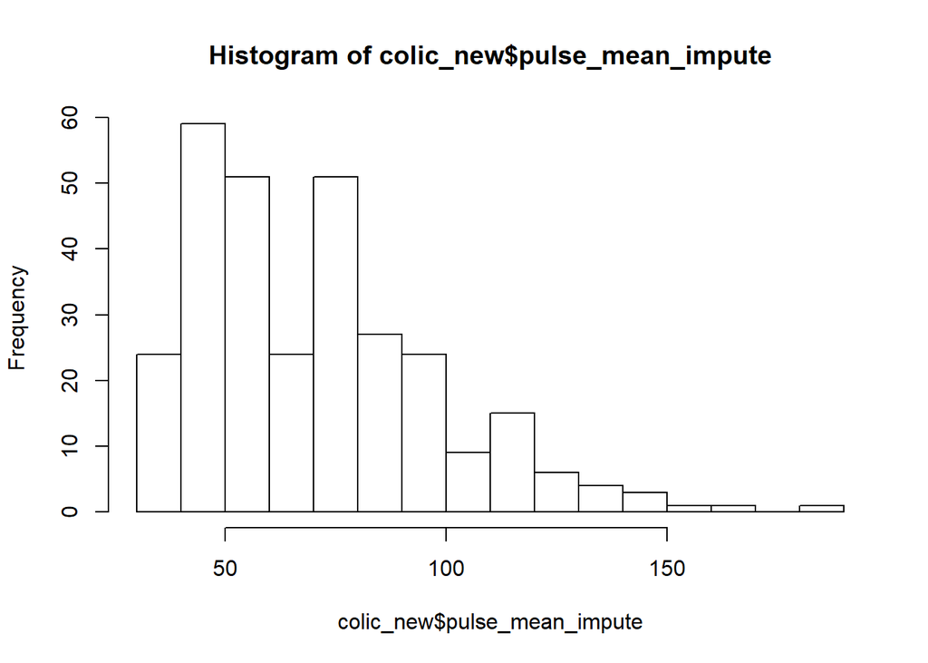

```r
hist(colic_new$pulse_mean_impute,15)
```

Notice that there is now a big ‘bump’ at the mean value. So we have not biased the mean, but we have biased the spread of the data (the standard deviation).

I am going to add two more columns of imputation. One will impute all missing values as low values (the 5th percentile), and the other will impute all values as ‘high’ values (the 95th percentile). This will allow a sensitivity test in a moment.

```r
# impute p5 by column
colic_new[,
          pulse_low_impute:=pulse]
colic_new[is.na(pulse),
          pulse_low_impute:=colic_new[,quantile(pulse,0.05,na.rm=TRUE)]]
# what happened?
hist(colic_new$pulse,15)
```

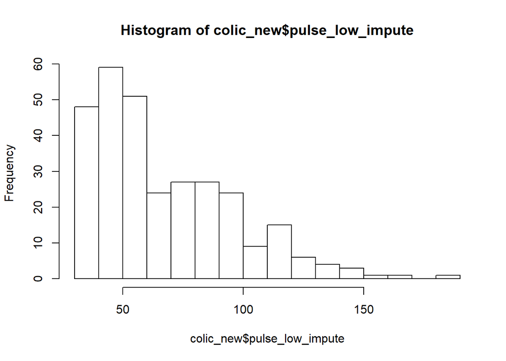

```r
hist(colic_new$pulse_low_impute,15)
```

```r
# impute p95 by column
colic_new[,
          pulse_high_impute:=pulse]
colic_new[is.na(pulse),
          pulse_high_impute:=colic_new[,quantile(pulse,0.95,na.rm=TRUE)]]
# what happened?
hist(colic_new$pulse,15)
```

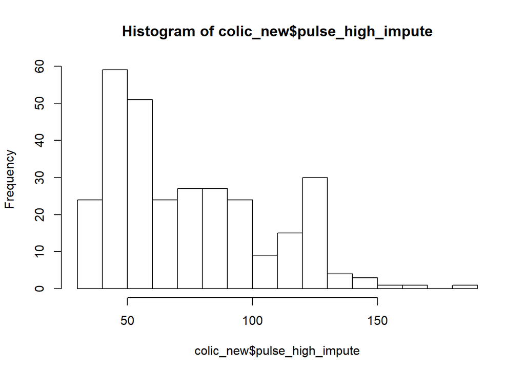

```r
hist(colic_new$pulse_high_impute,15)
```

# Sensitivity tests on missing data

Now we have three different versions of imputed data for the horse pulse.

Let’s ask and answer the question, is mean horse pulse related to the outcome of interest? And is the answer to this question sensitive to the missing data?

The outcome of interest here is what happened to the horse. The outcome has three levels:

1 = lived 2 = died 3 = was euthanized

I will recode this to simply be lived or died by combining the died and euthanized categories.

```r
colic_new[outcome == 1,outcome2 := 'lived']
colic_new[outcome %in% c(2,3),outcome2 := 'died']
colic_new[,table(outcome,outcome2)] # looks good
```

```
##        outcome2
## outcome died lived
##       1    0   178
##       2   77     0
##       3   44     0
```

Now we can do a basic analysis of the relationship between these two variables, using the various versions of pulse.

```r
colic_new[!is.na(outcome2),
          mean(pulse,na.rm=T),by=outcome2]
```

```
##    outcome2       V1
## 1:     died 85.06422
## 2:    lived 63.42169
```

```r
colic_new[!is.na(outcome2),
          mean(pulse_mean_impute,na.rm=T),by=outcome2]
```

```
##    outcome2       V1
## 1:     died 83.75997
## 2:    lived 63.99414
```

```r
colic_new[!is.na(outcome2),
          mean(pulse_low_impute,na.rm=T),by=outcome2]
```

```
##    outcome2       V1
## 1:     died 80.59504
## 2:    lived 61.84270
```

```r
colic_new[!is.na(outcome2),
          mean(pulse_high_impute,na.rm=T),by=outcome2]
```

```
##    outcome2       V1
## 1:     died 89.02479
## 2:    lived 67.57303
```

Look at these different results. Whether we ignore the missing data, impute the mean, impute it low, or impute it high, we still get the same qualitative answer to the analysis - horse who died had a much higher average pulse than horses who lived.

In this case, we would say the analysis is not **sensitive** to the missing data, so I feel safe ignoring it or imputing the mean.

If we had found something different - that the results depended on whether or not the missing values were high or low, then I would feel less confident in these results.

# Exercise

1. Analyze the `bmi` column of the pima dataset by `type` (whether the women have diabetes or not) by skin thickness and insulin following the steps below.
2. What is the mean of insulin level (`insulin`)? By type?
3. What is the mean ofskin thickness (`skin`)? By type?
4. What is the mean `bmi` by `type`?

# Answer

```r
summary(pima) #
```

```
##      npreg             glu              bp              skin          insulin            bmi             ped              age             type
##  Min.   : 0.000   Min.   : 44.0   Min.   : 24.00   Min.   : 7.00   Min.   : 14.00   Min.   :18.20   Min.   :0.0780   Min.   :21.00   Min.   :0.000
##  1st Qu.: 1.000   1st Qu.: 99.0   1st Qu.: 64.00   1st Qu.:22.00   1st Qu.: 76.25   1st Qu.:27.50   1st Qu.:0.2437   1st Qu.:24.00   1st Qu.:0.000
##  Median : 3.000   Median :117.0   Median : 72.00   Median :29.00   Median :125.00   Median :32.30   Median :0.3725   Median :29.00   Median :0.000
##  Mean   : 3.845   Mean   :121.7   Mean   : 72.41   Mean   :29.15   Mean   :155.55   Mean   :32.46   Mean   :0.4719   Mean   :33.24   Mean   :0.349
##  3rd Qu.: 6.000   3rd Qu.:141.0   3rd Qu.: 80.00   3rd Qu.:36.00   3rd Qu.:190.00   3rd Qu.:36.60   3rd Qu.:0.6262   3rd Qu.:41.00   3rd Qu.:1.000
##  Max.   :17.000   Max.   :199.0   Max.   :122.00   Max.   :99.00   Max.   :846.00   Max.   :67.10   Max.   :2.4200   Max.   :81.00   Max.   :1.000
##                   NA's   :5       NA's   :35       NA's   :227     NA's   :374      NA's   :11
```

```r
# or
pima_dt <- data.table(pima)
pima_dt[,.(mean(skin,na.rm=T),
           mean(insulin,na.rm=T))]
```

```
##          V1       V2
## 1: 29.15342 155.5482
```

```r
pima_dt[,mean(skin,na.rm=T),by=type]
```

```
##    type       V1
## 1:    1 33.00000
## 2:    0 27.23546
```

```r
pima_dt[,mean(insulin,na.rm=T),by=type]
```

```
##    type       V1
## 1:    1 206.8462
## 2:    0 130.2879
```

```r
pima_dt[,mean(bmi,na.rm=T),by=type]
```

```
##    type       V1
## 1:    1 35.40677
## 2:    0 30.85967
```

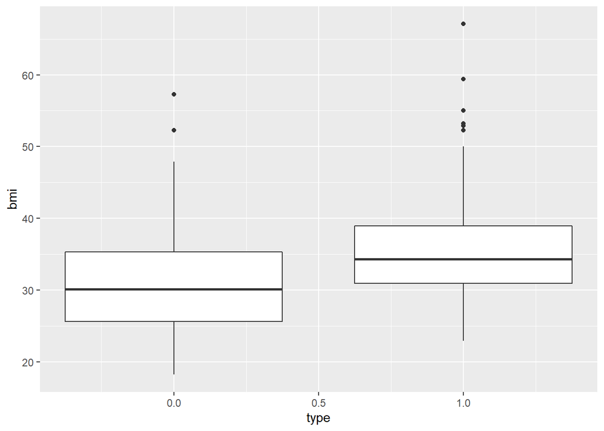

```r
ggplot(pima_dt,aes(type,bmi,group=type))+geom_boxplot()
```

# Exercise

1. Impute the mean for bmi.
2. Analyze diabetes by the imputed bmi. Does the relationship change?
3. Do the same for insulin and imputing by its mean.

# Answer

```r
#1
pima_new <- data.table(pima)
pima_new[,bmi_mean_impute:=bmi]
pima_new[is.na(bmi),
          bmi_mean_impute:=pima_new[,mean(bmi,na.rm=T)]]
pima_new
```

```
##      npreg glu bp skin insulin  bmi   ped age type bmi_mean_impute
##   1:     6 148 72   35      NA 33.6 0.627  50    1            33.6
##   2:     1  85 66   29      NA 26.6 0.351  31    0            26.6
##   3:     8 183 64   NA      NA 23.3 0.672  32    1            23.3
##   4:     1  89 66   23      94 28.1 0.167  21    0            28.1
##   5:     0 137 40   35     168 43.1 2.288  33    1            43.1
##  ---
## 764:    10 101 76   48     180 32.9 0.171  63    0            32.9
## 765:     2 122 70   27      NA 36.8 0.340  27    0            36.8
## 766:     5 121 72   23     112 26.2 0.245  30    0            26.2
## 767:     1 126 60   NA      NA 30.1 0.349  47    1            30.1
## 768:     1  93 70   31      NA 30.4 0.315  23    0            30.4
```

```r
summary(pima_new)
```

```
##      npreg             glu              bp              skin          insulin            bmi             ped              age             type
##  Min.   : 0.000   Min.   : 44.0   Min.   : 24.00   Min.   : 7.00   Min.   : 14.00   Min.   :18.20   Min.   :0.0780   Min.   :21.00   Min.   :0.000
##  1st Qu.: 1.000   1st Qu.: 99.0   1st Qu.: 64.00   1st Qu.:22.00   1st Qu.: 76.25   1st Qu.:27.50   1st Qu.:0.2437   1st Qu.:24.00   1st Qu.:0.000
##  Median : 3.000   Median :117.0   Median : 72.00   Median :29.00   Median :125.00   Median :32.30   Median :0.3725   Median :29.00   Median :0.000
##  Mean   : 3.845   Mean   :121.7   Mean   : 72.41   Mean   :29.15   Mean   :155.55   Mean   :32.46   Mean   :0.4719   Mean   :33.24   Mean   :0.349
##  3rd Qu.: 6.000   3rd Qu.:141.0   3rd Qu.: 80.00   3rd Qu.:36.00   3rd Qu.:190.00   3rd Qu.:36.60   3rd Qu.:0.6262   3rd Qu.:41.00   3rd Qu.:1.000
##  Max.   :17.000   Max.   :199.0   Max.   :122.00   Max.   :99.00   Max.   :846.00   Max.   :67.10   Max.   :2.4200   Max.   :81.00   Max.   :1.000
##                   NA's   :5       NA's   :35       NA's   :227     NA's   :374      NA's   :11
##  bmi_mean_impute
##  Min.   :18.20
##  1st Qu.:27.50
##  Median :32.40
##  Mean   :32.46
##  3rd Qu.:36.60
##  Max.   :67.10
##
```

```r
# 2
pima_new[,mean(bmi,na.rm=T),by=type]
```

```
##    type       V1
## 1:    1 35.40677
## 2:    0 30.85967
```

```r
pima_new[,mean(bmi_mean_impute,na.rm=T),by=type]
```

```
##    type       V1
## 1:    1 35.38476
## 2:    0 30.88843
```

```r
t.test(bmi~type,pima_new)
```

```
##
##  Welch Two Sample t-test
##
## data:  bmi by type
## t = -9.055, df = 539.79, p-value < 2.2e-16
## alternative hypothesis: true difference in means is not equal to 0
## 95 percent confidence interval:
##  -5.533527 -3.560659
## sample estimates:
## mean in group 0 mean in group 1
##        30.85967        35.40677
```

```r
t.test(bmi_mean_impute~type,pima_new)
```

```
##
##  Welch Two Sample t-test
##
## data:  bmi_mean_impute by type
## t = -9.0486, df = 539.54, p-value < 2.2e-16
## alternative hypothesis: true difference in means is not equal to 0
## 95 percent confidence interval:
##  -5.472436 -3.520209
## sample estimates:
## mean in group 0 mean in group 1
##        30.88843        35.38476
```

```r
#
# 3
pima_new[,insulin_mean_impute:=insulin]
pima_new[is.na(insulin),
          insulin_mean_impute:=pima_new[,mean(insulin,na.rm=T)]]
pima_new[,mean(insulin_mean_impute,na.rm=T),by=type]
```

```
##    type       V1
## 1:    1 180.1493
## 2:    0 141.9520
```

```r
t.test(insulin~type,pima_new)
```

```
##
##  Welch Two Sample t-test
##
## data:  insulin by type
## t = -5.7833, df = 207.14, p-value = 2.672e-08
## alternative hypothesis: true difference in means is not equal to 0
## 95 percent confidence interval:
##  -102.65630  -50.46025
## sample estimates:
## mean in group 0 mean in group 1
##        130.2879        206.8462
```

```r
t.test(insulin_mean_impute~type,pima_new)
```

```
##
##  Welch Two Sample t-test
##
## data:  insulin_mean_impute by type
## t = -5.6543, df = 447.36, p-value = 2.794e-08
## alternative hypothesis: true difference in means is not equal to 0
## 95 percent confidence interval:
##  -51.47363 -24.92088
## sample estimates:
## mean in group 0 mean in group 1
##        141.9520        180.1493
```

```r
# although the means change quite a bit, the conculsion doesn't.
# however, insulin is so severly missing (49%), that imputing it and using it for analysis
# is unwise.
```